# Access Sentinel2 data from CDSE

## Access Sentinel-2 data from the CDSE STAC catalog

### A DeepESDL example notebook

This notebook demonstrates how to access Sentinel-2 data from CDSE via xcube-stac store. The data is fetched via the [CDSE STAC API](https://browser.stac.dataspace.copernicus.eu/?.language=en).

**The data can be accessed via S3, where key and secret can be obtained following the [CDSE access documentation to EO data via S3](https://documentation.dataspace.copernicus.eu/APIs/S3.html#generate-secrets). The store object will receive the key and secret upon initialization, as demonstrated below.**

Please, also refer to the [DeepESDL documentation](https://deepesdl.readthedocs.io/en/latest/guide/jupyterlab/) and visit the platform's [website](https://www.earthsystemdatalab.net/) for further information!

Brockmann Consult, 2025

**This notebook runs with the python environment `users-deepesdl-xcube-1.11.0`, please checkout the documentation for [help on changing the environment](https://deepesdl.readthedocs.io/en/latest/guide/jupyterlab/#python-environment-selection-of-the-jupyter-kerne).**

```python
import itertools

import matplotlib.pyplot as plt
from xcube.core.store import new_data_store, get_data_store_params_schema

from xcube_stac.utils import reproject_bbox
```

import itertools import matplotlib.pyplot as plt from xcube.core.store import new_data_store, get_data_store_params_schema from xcube_stac.utils import reproject_bbox

**Store the credentials in a dictionary. If you don't have credentials yet, please folow the [CDSE access documentation to EO data via S3](https://documentation.dataspace.copernicus.eu/APIs/S3.html#generate-secrets) to obtain credentials.**

```python
credentials = {
    "key": "xxx",
    "secret": "xxx",
}
```

credentials = { "key": "xxx", "secret": "xxx", }

First, we get the store parameters needed to initialize a STAC [data store](https://xcube.readthedocs.io/en/latest/dataaccess.html#data-store-framework). Note that key and secret of the S3 access are required.

```python
%%time
store_params = get_data_store_params_schema("stac-cdse")
store_params
```

%%time store_params = get_data_store_params_schema("stac-cdse") store_params

```
CPU times: user 42.3 ms, sys: 42.5 ms, total: 84.9 ms
Wall time: 206 ms
```

```
<xcube.util.jsonschema.JsonObjectSchema at 0x7f91d80cd490>
```

Note that the user does not need to provide the URL for the [CDSE STAC API](https://documentation.dataspace.copernicus.eu/APIs/STAC.html). Only the key and secret for S3 access are required when initializing a `stac-cdse` [data store](https://xcube.readthedocs.io/en/latest/dataaccess.html#data-store-framework). First, we will initialize a store supporting the stacking mode. Then, for completeness, we will initialize a store in single-tile mode.

```python
%%time
store = new_data_store("stac-cdse", stack_mode=True, **credentials)
```

%%time store = new_data_store("stac-cdse", stack_mode=True, **credentials)

```
CPU times: user 11 ms, sys: 972 μs, total: 12 ms
Wall time: 171 ms
```

The data IDs point to a STAC collections. So far only `'sentinel-2-l2a'` is supported.

```python
%%time
#data_ids = store.list_data_ids()
#data_ids
```

%%time #data_ids = store.list_data_ids() #data_ids

```
CPU times: user 0 ns, sys: 3 μs, total: 3 μs
Wall time: 4.77 μs
```

Below, the parameters for the `open_data` method can be viewed.

```python
%%time
open_params = store.get_open_data_params_schema()
open_params
```

%%time open_params = store.get_open_data_params_schema() open_params

```
CPU times: user 31 μs, sys: 10 μs, total: 41 μs
Wall time: 42.4 μs
```

```
<xcube.util.jsonschema.JsonObjectSchema at 0x7f916f06b770>
```

So far, only data from the collection `sentinel-2-l2a` can be accessed. We therefore assign `data_id` to `"sentinel-2-l2a"`. We set the bounding box to cover the greater Hamburg area and the time range to second half of July 2020.

```python
%%time
ds = store.open_data(
    data_id="sentinel-2-l2a",
    bbox=[9.1, 53.1, 10.7, 54],
    time_range=["2020-07-15", "2020-08-01"],
    spatial_res=10 / 111320, # meter in degree
    crs="EPSG:4326",
    asset_names=["B02", "B03", "B04", "SCL"],
    apply_scaling=True,
    angles_sentinel2=True,
)
ds
```

%%time ds = store.open_data( data_id="sentinel-2-l2a", bbox=[9.1, 53.1, 10.7, 54], time_range=["2020-07-15", "2020-08-01"], spatial_res=10 / 111320, # meter in degree crs="EPSG:4326", asset_names=["B02", "B03", "B04", "SCL"], apply_scaling=True, angles_sentinel2=True, ) ds

```
CPU times: user 40.2 s, sys: 448 ms, total: 40.7 s
Wall time: 1min 24s
```

```
<xarray.Dataset> Size: 27GB
Dimensions:        (time: 11, lon: 17813, lat: 10020, angle_lon: 37,
                    angle_lat: 22, angle: 2, band: 3)
Coordinates:
  * time           (time) datetime64[ns] 88B 2020-07-15T10:15:59.024000 ... 2...
    spatial_ref    int64 8B 0
  * lon            (lon) float64 143kB 9.1 9.1 9.1 9.1 ... 10.7 10.7 10.7 10.7
  * lat            (lat) float64 80kB 54.0 54.0 54.0 54.0 ... 53.1 53.1 53.1
  * angle_lon      (angle_lon) float64 296B 9.1 9.146 9.191 ... 10.65 10.7 10.74
  * angle_lat      (angle_lat) float64 176B 54.04 54.0 53.95 ... 53.14 53.1
  * angle          (angle) object 16B 'zenith' 'azimuth'
  * band           (band) <U3 36B 'B02' 'B03' 'B04'
Data variables:
    B02            (time, lat, lon) float32 8GB dask.array<chunksize=(1, 2048, 2048), meta=np.ndarray>
    B03            (time, lat, lon) float32 8GB dask.array<chunksize=(1, 2048, 2048), meta=np.ndarray>
    B04            (time, lat, lon) float32 8GB dask.array<chunksize=(1, 2048, 2048), meta=np.ndarray>
    SCL            (time, lat, lon) uint16 4GB dask.array<chunksize=(1, 2048, 2048), meta=np.ndarray>
    solar_angle    (angle, time, angle_lat, angle_lon) float32 72kB dask.array<chunksize=(2, 1, 22, 37), meta=np.ndarray>
    viewing_angle  (angle, band, time, angle_lat, angle_lon) float32 215kB dask.array<chunksize=(2, 3, 1, 22, 37), meta=np.ndarray>
Attributes:
    stac_item_ids:     {'2020-07-15T10:15:59.024000': ['S2B_MSIL2A_20200715T1...
    stac_catalog_url:  https://stac.dataspace.copernicus.eu/v1
```

We can plot the B04 (red) band for a given timestamp as an example. Hereby a mosaicking of multiple tiles have been applied. Additionally, we plot the solar and viewing angle.

```python
%%time
fig, ax = plt.subplots(1, 3, figsize=(20, 6))
ds.B04.isel(time=-1)[::10, ::10].plot(ax=ax[0], vmin=0, vmax=0.2)
ds.solar_angle.isel(angle=0, time=-1).plot(ax=ax[1])
ds.viewing_angle.isel(band=2, angle=0, time=-1).plot(ax=ax[2])
```

%%time fig, ax = plt.subplots(1, 3, figsize=(20, 6)) ds.B04.isel(time=-1)[::10, ::10].plot(ax=ax[0], vmin=0, vmax=0.2) ds.solar_angle.isel(angle=0, time=-1).plot(ax=ax[1]) ds.viewing_angle.isel(band=2, angle=0, time=-1).plot(ax=ax[2])

```
CPU times: user 1min 27s, sys: 1.97 s, total: 1min 29s
Wall time: 1min 9s
```

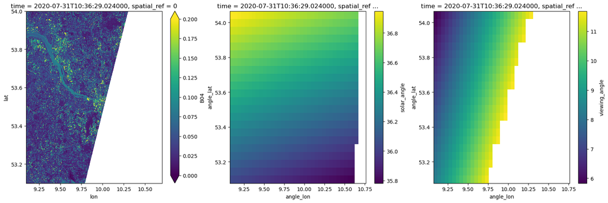

The data access can be speed up when requesting the data in the UTM CRS which is the native UTM of the Sentinel-2 products.

```python
%%time
bbox = [9.1, 53.1, 10.7, 54]
crs_target = "EPSG:32632"
bbox_utm = reproject_bbox(bbox, "EPSG:4326", crs_target)
```

%%time bbox = [9.1, 53.1, 10.7, 54] crs_target = "EPSG:32632" bbox_utm = reproject_bbox(bbox, "EPSG:4326", crs_target)

```
CPU times: user 1.28 ms, sys: 0 ns, total: 1.28 ms
Wall time: 731 μs
```

```python
%%time
ds = store.open_data(
    data_id="sentinel-2-l2a",
    bbox=bbox_utm,
    time_range=["2020-07-15", "2020-08-01"],
    spatial_res=10,
    crs=crs_target,
    asset_names=["B02", "B03", "B04", "SCL"],
    apply_scaling=True,
    angles_sentinel2=True,
)
ds
```

%%time ds = store.open_data( data_id="sentinel-2-l2a", bbox=bbox_utm, time_range=["2020-07-15", "2020-08-01"], spatial_res=10, crs=crs_target, asset_names=["B02", "B03", "B04", "SCL"], apply_scaling=True, angles_sentinel2=True, ) ds

```
CPU times: user 7.77 s, sys: 263 ms, total: 8.03 s
Wall time: 51.4 s
```

```
<xarray.Dataset> Size: 17GB
Dimensions:        (time: 11, y: 10147, x: 10727, angle_x: 23, angle_y: 22,
                    angle: 2, band: 3)
Coordinates:
  * time           (time) datetime64[ns] 88B 2020-07-15T10:15:59.024000 ... 2...
    spatial_ref    int64 8B 0
  * x              (x) float64 86kB 5.066e+05 5.066e+05 ... 6.138e+05 6.138e+05
  * y              (y) float64 81kB 5.985e+06 5.985e+06 ... 5.883e+06 5.883e+06
  * angle_x        (angle_x) float64 184B 5.066e+05 5.116e+05 ... 6.166e+05
  * angle_y        (angle_y) float64 176B 5.988e+06 5.983e+06 ... 5.883e+06
  * angle          (angle) object 16B 'zenith' 'azimuth'
  * band           (band) <U3 36B 'B02' 'B03' 'B04'
Data variables:
    B02            (time, y, x) float32 5GB dask.array<chunksize=(1, 2048, 2048), meta=np.ndarray>
    B03            (time, y, x) float32 5GB dask.array<chunksize=(1, 2048, 2048), meta=np.ndarray>
    B04            (time, y, x) float32 5GB dask.array<chunksize=(1, 2048, 2048), meta=np.ndarray>
    SCL            (time, y, x) uint16 2GB dask.array<chunksize=(1, 2048, 2048), meta=np.ndarray>
    solar_angle    (angle, time, angle_y, angle_x) float32 45kB dask.array<chunksize=(2, 1, 22, 23), meta=np.ndarray>
    viewing_angle  (angle, band, time, angle_y, angle_x) float32 134kB dask.array<chunksize=(2, 3, 1, 22, 23), meta=np.ndarray>
Attributes:
    stac_item_ids:     {'2020-07-15T10:15:59.024000': ['S2B_MSIL2A_20200715T1...
    stac_catalog_url:  https://stac.dataspace.copernicus.eu/v1
```

Note that the search function in the CDSE STAC API is very slow. Further investigation and comparison with other STAC APIs is needed.

We can plot the B04 (red) band for a given timestamp as an example. Hereby a mosaicking of multiple tiles have been applied. Additionally, we plot the solar and viewing angle.

```python
%%time
fig, ax = plt.subplots(1, 3, figsize=(20, 6))
ds.B04.isel(time=-1)[::10, ::10].plot(ax=ax[0], vmin=0, vmax=0.2)
ds.solar_angle.isel(angle=0, time=-1).plot(ax=ax[1])
ds.viewing_angle.isel(band=2, angle=0, time=-1).plot(ax=ax[2])
```

%%time fig, ax = plt.subplots(1, 3, figsize=(20, 6)) ds.B04.isel(time=-1)[::10, ::10].plot(ax=ax[0], vmin=0, vmax=0.2) ds.solar_angle.isel(angle=0, time=-1).plot(ax=ax[1]) ds.viewing_angle.isel(band=2, angle=0, time=-1).plot(ax=ax[2])

```
CPU times: user 58.1 s, sys: 795 ms, total: 58.8 s
Wall time: 37.7 s
```

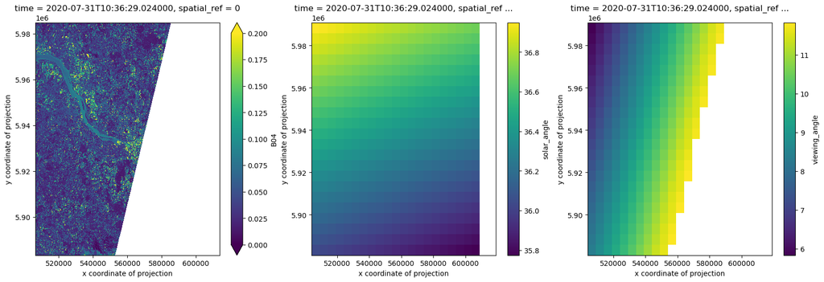

## Data store in the single-tile mode

For completeness, we initiate the data store in the single-tile mode and open data of one tile.

```python
%%time
store = new_data_store("stac-cdse", stack_mode=False, **credentials)
```

%%time store = new_data_store("stac-cdse", stack_mode=False, **credentials)

```
CPU times: user 9.98 ms, sys: 0 ns, total: 9.98 ms
Wall time: 88.8 ms
```

The data IDs point to a [STAC item's JSON](https://github.com/radiantearth/stac-spec/blob/master/item-spec/item-spec.md) and are specified by the segment of the URL that follows the catalog's URL. The data IDs can be streamed using the following code where we show the first 10 data IDs as an example.

⚠️ Warning: If you use `store.list_data_ids()` it will try to collect all Sentinel-2 tiles in the archive, before printing the result. This can take a while, and is not recommended.

```python
%%time
data_ids = store.get_data_ids()
list(itertools.islice(data_ids, 10))
```

%%time data_ids = store.get_data_ids() list(itertools.islice(data_ids, 10))

```
CPU times: user 11.4 ms, sys: 0 ns, total: 11.4 ms
Wall time: 667 ms
```

```
['collections/sentinel-1-grd/items/S1C_EW_GRDM_1SDV_20250612T082159_20250612T082242_002747_005A85_CD30_COG',
 'collections/sentinel-1-grd/items/S1C_EW_GRDM_1SDV_20250612T082059_20250612T082159_002747_005A85_C739_COG',
 'collections/sentinel-1-grd/items/S1C_EW_GRDM_1SDV_20250612T081959_20250612T082059_002747_005A85_9273_COG',
 'collections/sentinel-1-grd/items/S1C_EW_GRDM_1SDV_20250612T081855_20250612T081959_002747_005A85_F4FA_COG',
 'collections/sentinel-1-grd/items/S1C_EW_GRDM_1SDH_20250612T081357_20250612T081421_002747_005A83_6503_COG',
 'collections/sentinel-1-grd/items/S1C_EW_GRDM_1SDH_20250612T081257_20250612T081357_002747_005A83_8A20_COG',
 'collections/sentinel-1-grd/items/S1C_EW_GRDM_1SDH_20250612T081157_20250612T081257_002747_005A83_94F3_COG',
 'collections/sentinel-1-grd/items/S1C_EW_GRDM_1SDH_20250612T081057_20250612T081157_002747_005A83_EE29_COG',
 'collections/sentinel-1-grd/items/S1C_EW_GRDM_1SDH_20250612T080957_20250612T081057_002747_005A83_44A9_COG',
 'collections/sentinel-1-grd/items/S1C_EW_GRDM_1SDH_20250612T080857_20250612T080957_002747_005A83_3E51_COG']
```

In the next step, we can search for items using search parameters. The following code shows which search parameters are available.

```python
%%time
search_params = store.get_search_params_schema()
search_params
```

%%time search_params = store.get_search_params_schema() search_params

```
CPU times: user 32 μs, sys: 0 ns, total: 32 μs
Wall time: 34.8 μs
```

```
<xcube.util.jsonschema.JsonObjectSchema at 0x7f914d2dc560>
```

Next, we will search for tiles of Sentinel-2 data.

```python
%%time
descriptors = list(
    store.search_data(
        collections=["sentinel-2-l2a"],
        bbox=[9, 47, 10, 48],
        time_range=["2020-07-01", "2020-07-05"],
    )
)
[d.to_dict() for d in descriptors]
```

%%time descriptors = list( store.search_data( collections=["sentinel-2-l2a"], bbox=[9, 47, 10, 48], time_range=["2020-07-01", "2020-07-05"], ) ) [d.to_dict() for d in descriptors]

```
CPU times: user 208 ms, sys: 4.01 ms, total: 212 ms
Wall time: 2.05 s
```

```
[{'data_id': 'collections/sentinel-2-l2a/items/S2B_MSIL2A_20200705T101559_N0500_R065_T32UNU_20230530T175912',
  'data_type': 'dataset',
  'bbox': [8.999728, 47.755819, 10.493269, 48.753013],
  'time_range': ('2020-07-05T10:15:59.024Z', '2020-07-05T10:15:59.024Z')},
 {'data_id': 'collections/sentinel-2-l2a/items/S2B_MSIL2A_20200705T101559_N0500_R065_T32UMU_20230530T175912',
  'data_type': 'dataset',
  'bbox': [8.087776, 47.759622, 9.132783, 48.752937],
  'time_range': ('2020-07-05T10:15:59.024Z', '2020-07-05T10:15:59.024Z')},
 {'data_id': 'collections/sentinel-2-l2a/items/S2B_MSIL2A_20200705T101559_N0500_R065_T32TNT_20230530T175912',
  'data_type': 'dataset',
  'bbox': [8.999733, 46.85664, 10.467277, 47.853702],
  'time_range': ('2020-07-05T10:15:59.024Z', '2020-07-05T10:15:59.024Z')},
 {'data_id': 'collections/sentinel-2-l2a/items/S2B_MSIL2A_20200705T101559_N0500_R065_T32TMT_20230530T175912',
  'data_type': 'dataset',
  'bbox': [7.760786, 46.858555, 9.13047, 47.853628],
  'time_range': ('2020-07-05T10:15:59.024Z', '2020-07-05T10:15:59.024Z')},
 {'data_id': 'collections/sentinel-2-l2a/items/S2A_MSIL2A_20200703T103031_N0500_R108_T32UNU_20230613T212700',
  'data_type': 'dataset',
  'bbox': [8.999728, 47.761055, 10.094773, 48.753013],
  'time_range': ('2020-07-03T10:30:31.024Z', '2020-07-03T10:30:31.024Z')},
 {'data_id': 'collections/sentinel-2-l2a/items/S2A_MSIL2A_20200703T103031_N0500_R108_T32UMU_20230613T212700',
  'data_type': 'dataset',
  'bbox': [7.639177, 47.757404, 9.132783, 48.752937],
  'time_range': ('2020-07-03T10:30:31.024Z', '2020-07-03T10:30:31.024Z')},
 {'data_id': 'collections/sentinel-2-l2a/items/S2A_MSIL2A_20200703T103031_N0500_R108_T32TNT_20230613T212700',
  'data_type': 'dataset',
  'bbox': [8.999733, 46.864171, 9.68382, 47.853702],
  'time_range': ('2020-07-03T10:30:31.024Z', '2020-07-03T10:30:31.024Z')},
 {'data_id': 'collections/sentinel-2-l2a/items/S2A_MSIL2A_20200703T103031_N0500_R108_T32TMT_20230613T212700',
  'data_type': 'dataset',
  'bbox': [7.662865, 46.858176, 9.13047, 47.853628],
  'time_range': ('2020-07-03T10:30:31.024Z', '2020-07-03T10:30:31.024Z')}]
```

In the next step, we can open the data for each data ID. The following code shows which parameters are available for opening the data.

```python
%%time
open_params = store.get_open_data_params_schema()
open_params
```

%%time open_params = store.get_open_data_params_schema() open_params

```
CPU times: user 36 μs, sys: 0 ns, total: 36 μs
Wall time: 39.1 μs
```

```
<xcube.util.jsonschema.JsonObjectSchema at 0x7f914ff5ac30>
```

We select the band B04 (red), B03 (green), B02 (blue), and the science classification layer (SLC), and lazily load the corresponding data.

```python
%%time
ds = store.open_data(
    "collections/sentinel-2-l2a/items/S2B_MSIL2A_20200705T101559_N0500_R065_T32TMT_20230530T175912",
    asset_names=["B04", "B03", "B02", "SCL"],
    apply_scaling=True,
    angles_sentinel2=True,
)
ds
```

%%time ds = store.open_data( "collections/sentinel-2-l2a/items/S2B_MSIL2A_20200705T101559_N0500_R065_T32TMT_20230530T175912", asset_names=["B04", "B03", "B02", "SCL"], apply_scaling=True, angles_sentinel2=True, ) ds

```
CPU times: user 301 ms, sys: 12.4 ms, total: 313 ms
Wall time: 1.79 s
```

```
<xarray.Dataset> Size: 2GB
Dimensions:        (y: 10980, x: 10980, angle_x: 23, angle_y: 23, angle: 2,
                    band: 3)
Coordinates:
    spatial_ref    int64 8B 0
  * x              (x) float64 88kB 4e+05 4e+05 4e+05 ... 5.097e+05 5.098e+05
  * y              (y) float64 88kB 5.3e+06 5.3e+06 ... 5.19e+06 5.19e+06
  * angle_x        (angle_x) float64 184B 4e+05 4.05e+05 ... 5.05e+05 5.1e+05
  * angle_y        (angle_y) float64 184B 5.3e+06 5.295e+06 ... 5.19e+06
  * angle          (angle) object 16B 'zenith' 'azimuth'
  * band           (band) <U3 36B 'B02' 'B03' 'B04'
Data variables:
    B04            (y, x) float32 482MB dask.array<chunksize=(10980, 10980), meta=np.ndarray>
    B03            (y, x) float32 482MB dask.array<chunksize=(10980, 10980), meta=np.ndarray>
    B02            (y, x) float32 482MB dask.array<chunksize=(10980, 10980), meta=np.ndarray>
    SCL            (y, x) uint8 121MB dask.array<chunksize=(10980, 10980), meta=np.ndarray>
    solar_angle    (angle, angle_y, angle_x) float32 4kB dask.array<chunksize=(2, 23, 23), meta=np.ndarray>
    viewing_angle  (angle, band, angle_y, angle_x) float32 13kB dask.array<chunksize=(2, 3, 23, 23), meta=np.ndarray>
Attributes:
    stac_catalog_url:  https://stac.dataspace.copernicus.eu/v1
    stac_item_id:      S2B_MSIL2A_20200705T101559_N0500_R065_T32TMT_20230530T...
```

We plot the loaded data as an example below.

```python
%%time
ds.B04[::10, ::10].plot(vmin=0.0, vmax=0.2)
```

%%time ds.B04[::10, ::10].plot(vmin=0.0, vmax=0.2)

```
CPU times: user 16 s, sys: 354 ms, total: 16.4 s
Wall time: 10.5 s
```

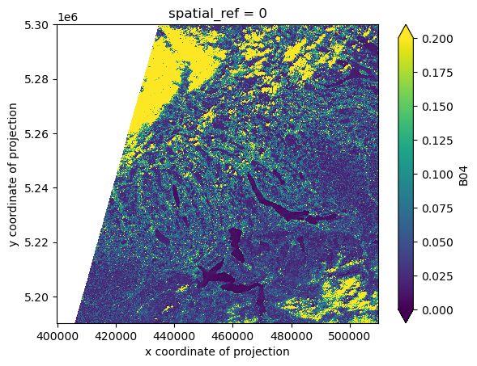

We can also open a `.jp2` as a [xcube's multi-resolution dataset](https://xcube.readthedocs.io/en/latest/mldatasets.html#xcube-multi-resolution-datasets), where we can select the level of resolution, shown below.

```python
%%time
mlds = store.open_data(
    descriptors[3].data_id,
    data_type="mldataset",
    asset_names=["B04", "B03", "B02"],
    apply_scaling=True,
    angles_sentinel2=True,
)
mlds.num_levels
```

%%time mlds = store.open_data( descriptors[3].data_id, data_type="mldataset", asset_names=["B04", "B03", "B02"], apply_scaling=True, angles_sentinel2=True, ) mlds.num_levels

```
CPU times: user 18.5 ms, sys: 3.89 ms, total: 22.3 ms
Wall time: 738 ms
```

```
5
```

```python
%%time
ds = mlds.get_dataset(2)
ds
```

%%time ds = mlds.get_dataset(2) ds

```
CPU times: user 201 ms, sys: 74 μs, total: 202 ms
Wall time: 708 ms
```

```
<xarray.Dataset> Size: 90MB
Dimensions:        (x: 2745, y: 2745, angle_x: 23, angle_y: 23, angle: 2,
                    band: 3)
Coordinates:
  * x              (x) float64 22kB 4e+05 4e+05 ... 5.097e+05 5.097e+05
  * y              (y) float64 22kB 5.3e+06 5.3e+06 ... 5.19e+06 5.19e+06
    spatial_ref    int64 8B 0
  * angle_x        (angle_x) float64 184B 4e+05 4.05e+05 ... 5.05e+05 5.1e+05
  * angle_y        (angle_y) float64 184B 5.3e+06 5.295e+06 ... 5.19e+06
  * angle          (angle) object 16B 'zenith' 'azimuth'
  * band           (band) <U3 36B 'B02' 'B03' 'B04'
Data variables:
    B04            (y, x) float32 30MB dask.array<chunksize=(256, 256), meta=np.ndarray>
    B03            (y, x) float32 30MB dask.array<chunksize=(256, 256), meta=np.ndarray>
    B02            (y, x) float32 30MB dask.array<chunksize=(256, 256), meta=np.ndarray>
    solar_angle    (angle, angle_y, angle_x) float32 4kB dask.array<chunksize=(2, 23, 23), meta=np.ndarray>
    viewing_angle  (angle, band, angle_y, angle_x) float32 13kB dask.array<chunksize=(2, 3, 23, 23), meta=np.ndarray>
Attributes:
    stac_catalog_url:  https://stac.dataspace.copernicus.eu/v1
    stac_item_id:      S2B_MSIL2A_20200705T101559_N0500_R065_T32TMT_20230530T...
```

```python
%%time
ds.B04[::10, ::10].plot(vmin=0.0, vmax=0.2)
```

%%time ds.B04[::10, ::10].plot(vmin=0.0, vmax=0.2)

```
CPU times: user 1.6 s, sys: 146 ms, total: 1.75 s
Wall time: 8.8 s
```

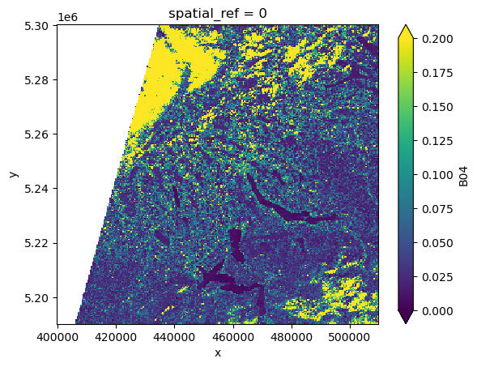